# Prosper Loan Data Exploration

## Dataset Overview

> The original data consisted of approximately 114000 records (loans) and 80 attributes. Some of these features had missing values. After removing these missing values, the resulting dataset had approximately 76000 records. Also out 80 attributes we kept 8 and wanted to see whether they affect the borrowers' Prosper Score. These attributes are:
> - `ProsperScore` *`IncomeVerifiable`*`IsBorrowerHomeowner` *`RevolvingCreditBalance`*`DebtToIncomeRatio` *`StatedMonthlyIncome`*`CurrentDelinquencies` *`TotalInquires`* `AvailableBankcardCredit`

## Distributions of attributes

Most of the variables have skewed distributions. However, applying a log transformation to some of these attributes their dstributions become more symmetric.

## Distribution of `ProsperScore`

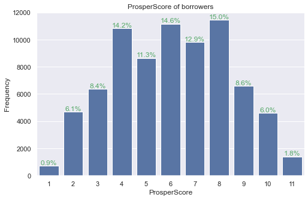

## Distribution of `IsBorrowerHomeowner` and `IncomeVerifiable`

According to the below bar charts the income can be verified for the majority of the borrowers and there are almost two equal groups of borrowers who owe a home and who don't.

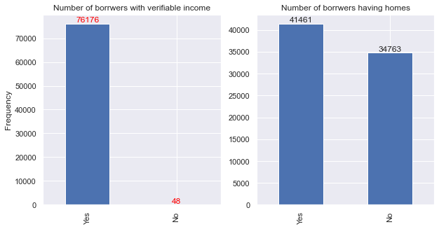

## Distribution of `DebtToIncomeRatio`

99% of the borrowers owe less maney than they make. As a result, 99% of the values lie in the interval [0,0.72] with the distribution being skeed to the right. Most of the borrowers owe between 0.1 and 0.3 of their income. Only 322 borrowers owe more money than they make. Applying a log transformation to the attribute `DebtToIncomeRatio` its distribution becomes more symmetric.

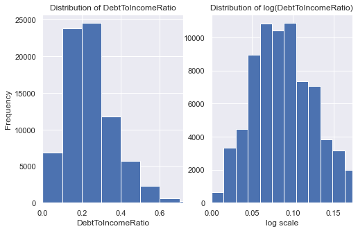

## Distribution of `RevolvingCreditBalance`

According to the first histogram (before a log transformation) the major bulk of the data is accumulated on the left side of the x-axis. Furthermore, 97 % of the data lie between 1 and 142000. As a result, the data is skewed to the right. It seems the distributaion of this data could have possible come from a Gamma distribution. However, applying a log transform to `RevolvingCreditBalance` after removing very small values or big values,we can see that the distribution of log `RevolvingCreditBalance` could have almost come from a Normal distribution except for that left tail.

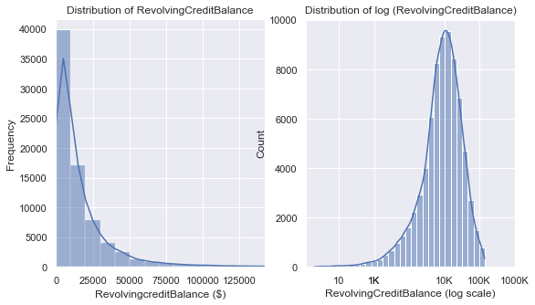

## Distribution of `AvailableBankcardCredit`

The distribution of `AvailableBankcardCredit` is skewed to the right as well. Also, only 2.92% of the vlues are less than 1 and 1% values are larger than 84000. However, applying a log transformation after we have removed the really small and very big values, we see that the distribution of log(`AvailableBankcardCredit`) becomes more symmetric with some extended left tail.

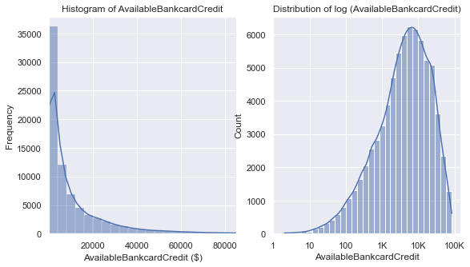

## Distribution of `StatedMonthlyIncome`

The data appears to be skewed to the right. Only 2% of the data lie outside of the range [1200,21000]. After applying a log transformation the distribution becomes more symmetric and it appears to be almost bimodal.

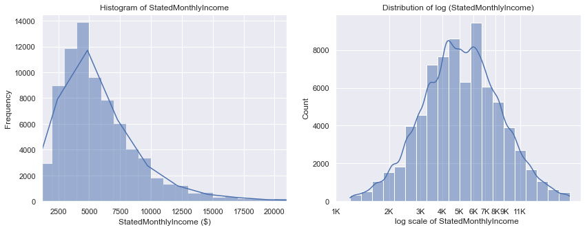

## Distribution of `TotalInquiries`

The frequency of total inquiries decreasing gradually and the distribution of `TotalInquiries` seems to be skewed to the right. Only 1% of the values are larger than 18 so these values can be considered unusual.

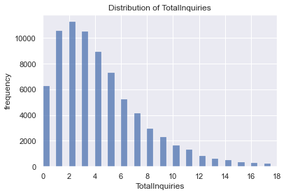

## Distribution of CurrentDelinquencies

90% of the borrowers have 0 or 1 delinquencies. Anything larger than 2 can be considered as an usual value.

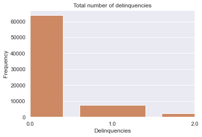

- `RevovlingCreditBalance` vs `ProsperScore`
- `AvailableBankcardCredit` vs `ProsperScore`
- `DebtoToIncomeRatio` vs `ProsperScore`
- `StatedMonthlyIncome` vs `ProsperScore`

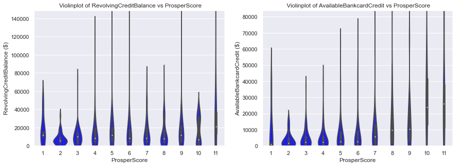

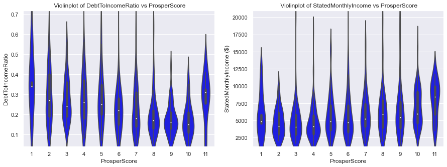

- `CurrentDelinquencies` vs `ProsperScore`
- `TotalInquires` vs `ProsperScore`

From the pointplot `CurrentDelinquencies` vs `ProsperScore`, we see that the average delinquencies drops down drastically after score 1(high risk). Another thing we can observe that high scores (9,10,11, i.e. low risk) are assigned with very low number of delinquencies.

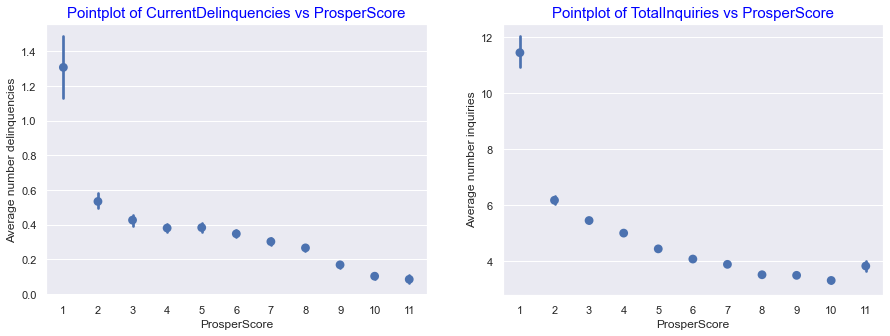

## `IsBorrowerHomeowner` vs `ProsperScore`

It seems that there is some interaction between `ProsperScore`and `IsBorrowerHomeowner` especially for the range of big scores [5,11]. We can see that the higher the score gets in the range [5,11] the more frequently it is assigned to home owners.

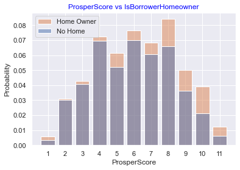

## `PropserScore` vs `RevolvingCreditBalance` and `IsBorrowerHomeowner`

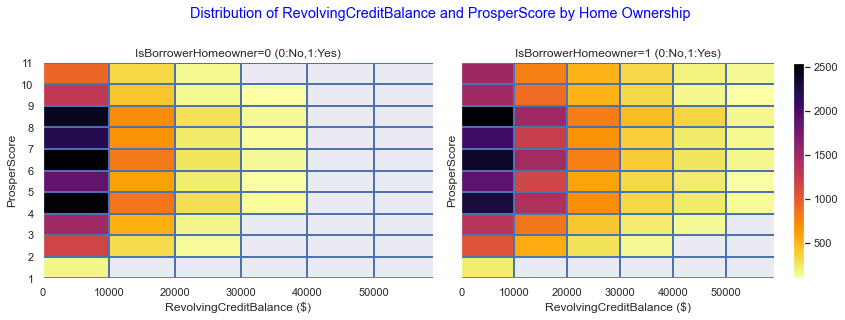

## `ProsperScore` vs `DebtToIncomeRatio` and `IncomeVerifiable`

As it is indicated below, the attribute `IncomeVerifiable` affects the relationship between `DebtToIncomeratio` and `ProsperScore`. In fact, the borrowers who can justify their income are assigned fairly high scores even if their debt to income ratio is kind of big and this fact explains to some extent the reason we saw a jump up at score 11 (low risk) after a decreasing trend of`DebtToIncomeratio` vs `ProsperScore`. However, we have to take into our account that we did not have much data about the borrowers whose income wasn't verifiable.

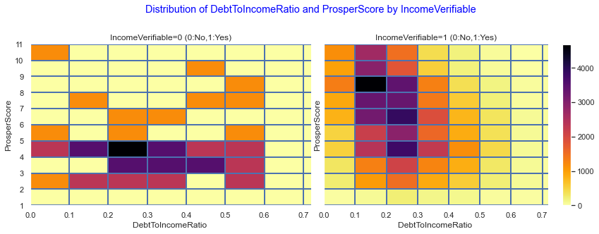